# Simulating the Revenue and Health Impact of HB 11360

AJ Montesa

2025-02-11

### Formulas

**Formula for Cigarette Taxes and Retail Prices**
$$\text{Retail Price} = [\text{Net-of-Tax Price } + \text{ Specific Excise
Tax}]\times(1+\text{VAT rate})$$

$$\text{Net-of-Tax Price} = \frac{\text{Retail Price}}{(1+\text{VAT
rate})} - \text{ Specific Excise Tax}$$

**Point Elasticity Formula**
$$\varepsilon_p = \frac{(Q_2-Q_2)/Q_1}{(P_2-P_2)/P_1}$$

$$Q_2 = Q_1 \times [1+\varepsilon_p(\frac{P_2-P_1}{P_1})]$$

**Change in consumption, accounting for income and population growth**
$$Q_2 = [Q_1 \times (1+ \varepsilon_{Y} \% \Delta Y) \times (1+\% \Delta
Population)] \times [1+\varepsilon_p(\frac{P_2-P_1}{P_1}-\%\Delta CPI)]$$

**Change in smoking population, given prevalence elasticity $\rho$**
$$\text{Smoking Population}_2 = \text{Smoking Population}_1 \times
[1+\rho(2\frac{Q_2-Q_1}{Q_2+Q_1})]$$

### Macroeconmic, Demographic, and Behavioral assumptions

- Own-price elasticity of cigarettes $\varepsilon_p$ : -0.4
- Income elasticity of cigarettes $\varepsilon_Y$ : 0.55
- Prevalence elasticity $\rho$ : 0.5
- Average annual per capita income growth rate $\%\Delta Y$ : 3.5%
- Average annual population growth rate : 0.8%
- Average annual inflation rate $\%\Delta CPI$ : 3.0%
- Smoking prevalence among adults : 23.0%
- Adult population : 67,427,157

```r
price_elasticity <- -0.4

income_elasticity <- 0.55
income_growth <- 0.035

population_growth <- 0.008
inflation_rate <- 0.03

smoking_prevalence <- 0.23
adult_population <- 64793612*((1+population_growth)^(2025-2020))
smoking_population <- smoking_prevalence*adult_population

prevalence_elasticity <- 0.5
netoftax_increase <- 0.05
```

### Set Starting Values (2025)

- Specific tax rate per pack of cigarettes : PHP66.15
- Retail price per pack : PHP150.00
- Value-Added Tax (VAT) : 12%
- Annual net-of-tax price increase : 5%
- Initial quantity : 1,965,230,537 packs

```r
# 2025 figures
excise_perpack <- 66.15
excise_revenue <- 130e9

q1 <- excise_revenue/excise_perpack

retail_perpack <- 150

vat_rate <- 0.12
vat_perpack <- retail_perpack*(vat_rate/(1+vat_rate))

totaltax_perpack <- excise_perpack + vat_perpack

netoftax_perpack <- retail_perpack - totaltax_perpack
```

### Simulating Baseline Projections

- From 2026 onwards, the specific tax rate is increased by 5% annually.
- Before income and price effects, we project that total consumption will grow at the same rate as population growth.
- Income growth will also increase consumption of cigarettes by a factor determined by the assumed income elasticity.
- Finally, consumption will fall by a factor determined by the *real* increase in prices. That is, the increase in retail prices minus the average inflation rate. Furthermore, we assume that cigarette manufacturers will increases prices independent of the excise taxes.
- The baseline simulation is used to compare versus the policy proposal.

```r
indexation <- 0.05

baseline <- tibble(
  Year = as.Date(str_c(c(2025:2035), "-01-01")),
) %>%
  mutate(
    Excise_PerPack = round(excise_perpack*(1+indexation)^(row_number()-1), 2),
    NetofTax_PerPack = round(netoftax_perpack*(1+netoftax_increase)^(row_number()-1), 2),
    Retail_PerPack = round(( NetofTax_PerPack + Excise_PerPack )*(1+vat_rate), 2),
    Multiplier = 1+(price_elasticity*((Retail_PerPack-lag(Retail_PerPack))/lag(Retail_PerPack)-inflation_rate)),
    #Multiplier_Arc = (1+elasticity*((Retail_Price-lag(Retail_Price))/(Retail_Price+lag(Retail_Price)))/1+elasticity*((Retail_Price-lag(Retail_Price))/(Retail_Price+lag(Retail_Price))))
  )

Quantity = c(q1)

for(i in 2:11) {
  Quantity <- c(Quantity, (Quantity[i-1] * (1+(income_growth*income_elasticity)) * (1+population_growth)) * baseline$Multiplier[i])
}

baseline <- baseline %>%
  bind_cols(tibble(Quantity)) %>%
  mutate(Excise_Revenue = Quantity*Excise_PerPack,
         Prevalence_Multiplier = 1+(prevalence_elasticity*(2*(Quantity-lag(Quantity))/(Quantity+lag(Quantity)))))

Smoking_Population = c(smoking_population)

for(i in 2:11) {
  Smoking_Population <- c(Smoking_Population, (Smoking_Population[i-1] * baseline$Prevalence_Multiplier[i]))
}

baseline <- baseline %>%
  bind_cols(tibble(Smoking_Population)) %>%
  mutate(Adult_Population = round(adult_population*(1+population_growth)^(row_number()-1), 2),
         Smoking_Prevalence = Smoking_Population/Adult_Population)
```

### Simulating Impact of House Bill No. 11360

- In lieu of the 5% annual indexation, HB 11360 proposes that, beginning 2026, the excise taxes on tobacco products will be increased by 2% every even-numbered year and 4% every odd-numbered year.
- After a ten-year period, a review of the impact of the tax on revenue, health, and smoking prevalence will be conducted.

```r
## HB 11360
HB_Indexation <- c(1, rep(c(1.02, 1.04), 5))
HB_Excise_PerPack <- c(excise_perpack)

for(i in 2:11) {
  HB_Excise_PerPack <- c(HB_Excise_PerPack, HB_Excise_PerPack[i-1]*HB_Indexation[i])
}


hb_sim <- tibble(
  Year = as.Date(str_c(c(2025:2035), "-01-01")),
  HB_Excise_PerPack = round(HB_Excise_PerPack, 2)
) %>%
  mutate(NetofTax_PerPack = round(netoftax_perpack*(1+netoftax_increase)^(row_number()-1), 2),
         HB_Retail_PerPack = round(( NetofTax_PerPack + HB_Excise_PerPack )*(1+vat_rate), 2),
         HB_Multiplier = 1+(price_elasticity*((HB_Retail_PerPack-lag(HB_Retail_PerPack))/lag(HB_Retail_PerPack)-inflation_rate))
         )

HB_Quantity = c(q1)

for(i in 2:11) {
  HB_Quantity <- c(HB_Quantity, (HB_Quantity[i-1] * (1+(income_growth*income_elasticity)) * (1+population_growth)) * hb_sim$HB_Multiplier[i])
}

hb_sim <- hb_sim %>%
  bind_cols(tibble(HB_Quantity)) %>%
  mutate(HB_Excise_Revenue = HB_Quantity*HB_Excise_PerPack,
         HB_Prevalence_Multiplier = 1+(prevalence_elasticity*(2*(HB_Quantity-lag(HB_Quantity))/(HB_Quantity+lag(HB_Quantity)))))

HB_Smoking_Population = c(smoking_population)

for(i in 2:11) {
  HB_Smoking_Population <- c(HB_Smoking_Population, (HB_Smoking_Population[i-1] * hb_sim$HB_Prevalence_Multiplier[i]))
}

hb_sim <- hb_sim %>%
  bind_cols(tibble(HB_Smoking_Population)) %>%
  mutate(Adult_Population = round(adult_population*(1+population_growth)^(row_number()-1), 2),
         HB_Smoking_Prevalence = HB_Smoking_Population/Adult_Population)
```

### Simulation Results

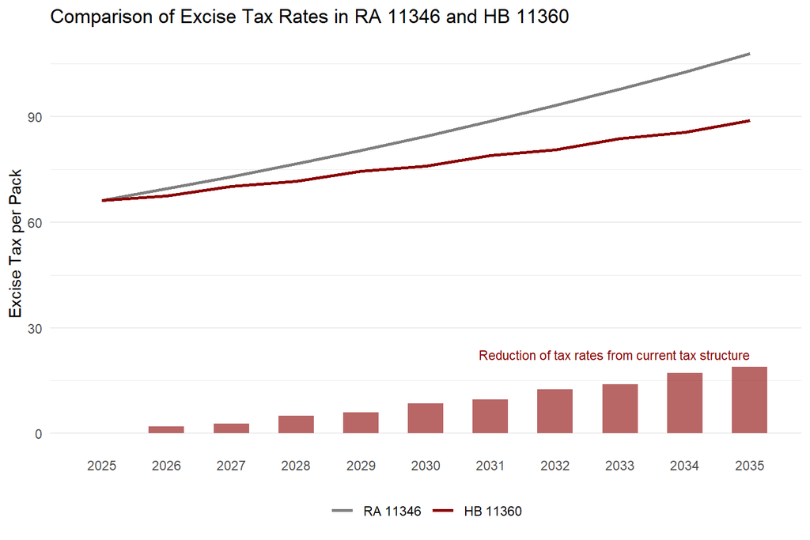

| Year | Excise_PerPack | HB_Excise_PerPack | Retail_PerPack | HB_Retail_PerPack | Quantity | HB_Quantity | Excise_Revenue | HB_Excise_Revenue | Smoking_Population | HB_Smoking_Population |
| --- | --- | --- | --- | --- | --- | --- | --- | --- | --- | --- |
| 2025 | 66.2 | 66.2 | 150.0 | 150.0 | 1,965,230,537 | 1,965,230,537 | 130,000,000,000 | 130,000,000,000 | 15,508,246 | 15,508,246 |
| 2026 | 69.5 | 67.5 | 157.5 | 155.3 | 2,002,879,186 | 2,014,886,016 | 139,119,988,279 | 135,944,359,500 | 15,655,385 | 15,701,725 |
| 2027 | 72.9 | 70.2 | 165.4 | 162.3 | 2,041,332,700 | 2,057,561,891 | 148,874,393,839 | 144,379,117,906 | 15,804,241 | 15,866,266 |
| 2028 | 76.6 | 71.6 | 173.6 | 168.0 | 2,080,540,848 | 2,109,355,484 | 159,327,818,155 | 150,987,665,506 | 15,954,575 | 16,063,480 |
| 2029 | 80.4 | 74.4 | 182.3 | 175.7 | 2,120,366,908 | 2,153,908,651 | 170,498,703,049 | 160,336,960,005 | 16,105,830 | 16,231,351 |
| 2030 | 84.4 | 75.9 | 191.4 | 181.9 | 2,161,126,897 | 2,207,892,426 | 182,463,943,885 | 167,645,271,940 | 16,259,158 | 16,432,238 |
| 2031 | 88.7 | 79.0 | 201.0 | 190.2 | 2,202,550,501 | 2,254,519,786 | 195,256,101,887 | 178,016,882,280 | 16,413,503 | 16,603,937 |
| 2032 | 93.1 | 80.5 | 211.1 | 197.0 | 2,244,855,453 | 2,310,674,138 | 208,951,145,514 | 186,101,695,049 | 16,569,633 | 16,808,174 |
| 2033 | 97.7 | 83.8 | 221.6 | 206.0 | 2,287,935,597 | 2,359,298,333 | 223,599,945,855 | 197,638,421,340 | 16,727,112 | 16,983,183 |
| 2034 | 102.6 | 85.4 | 232.7 | 213.5 | 2,331,788,803 | 2,417,830,411 | 239,288,166,997 | 206,579,430,296 | 16,885,896 | 17,191,270 |
| 2035 | 107.8 | 88.9 | 244.3 | 223.2 | 2,376,544,221 | 2,468,698,597 | 256,072,639,802 | 219,368,557,349 | 17,046,406 | 17,370,229 |

### Revenue Impact

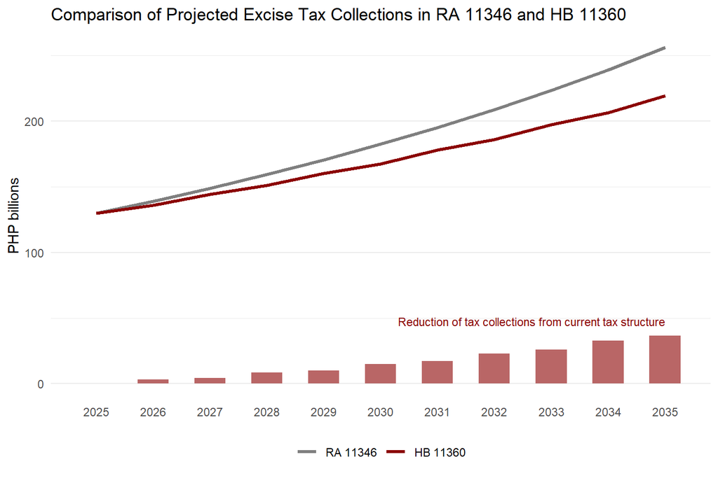

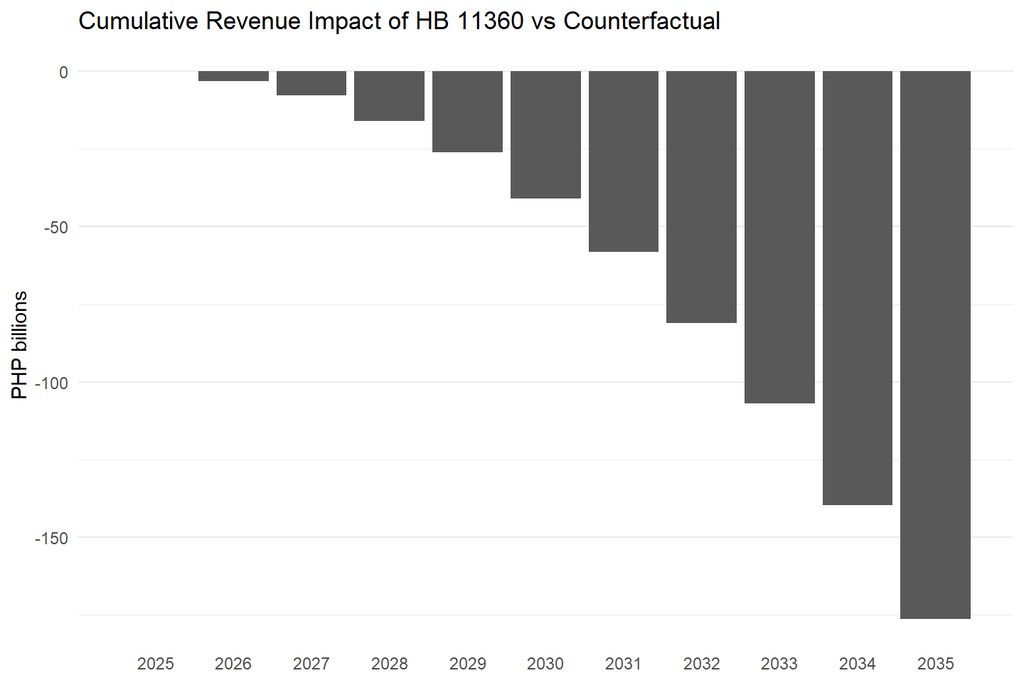

### Health Impact

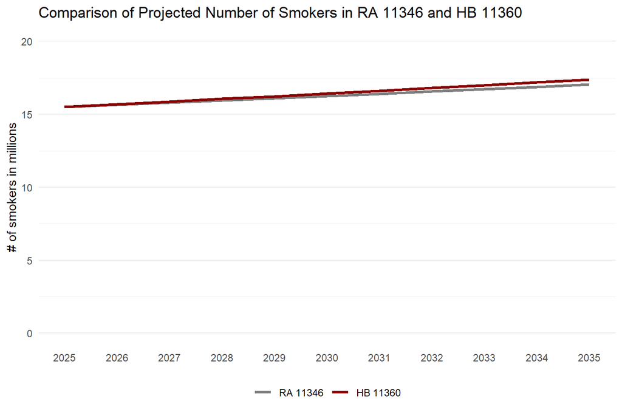

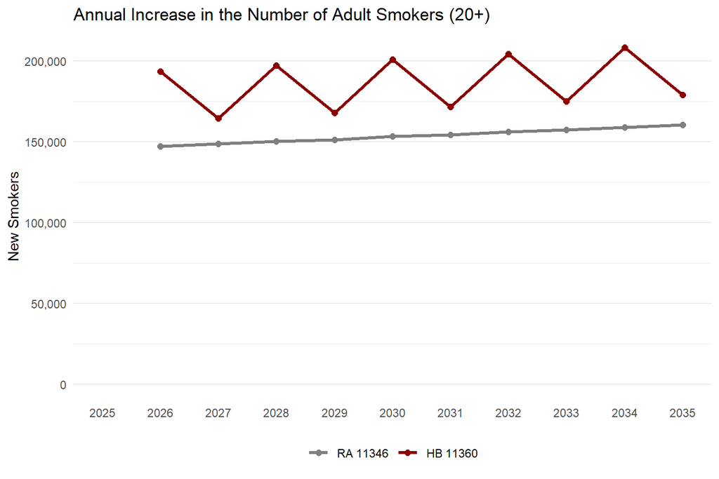

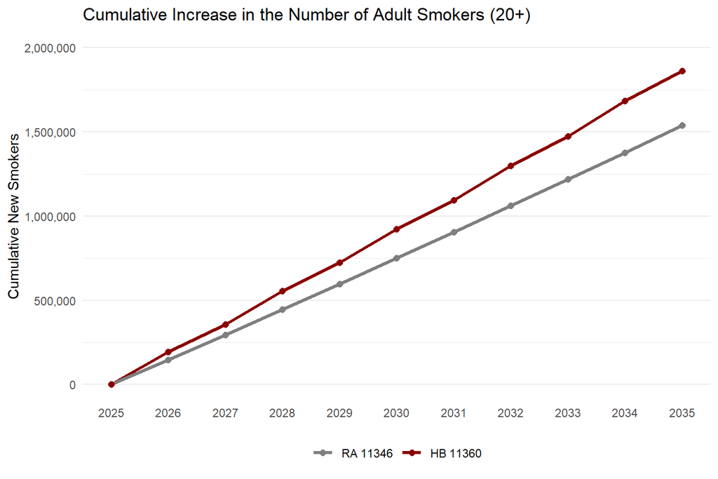

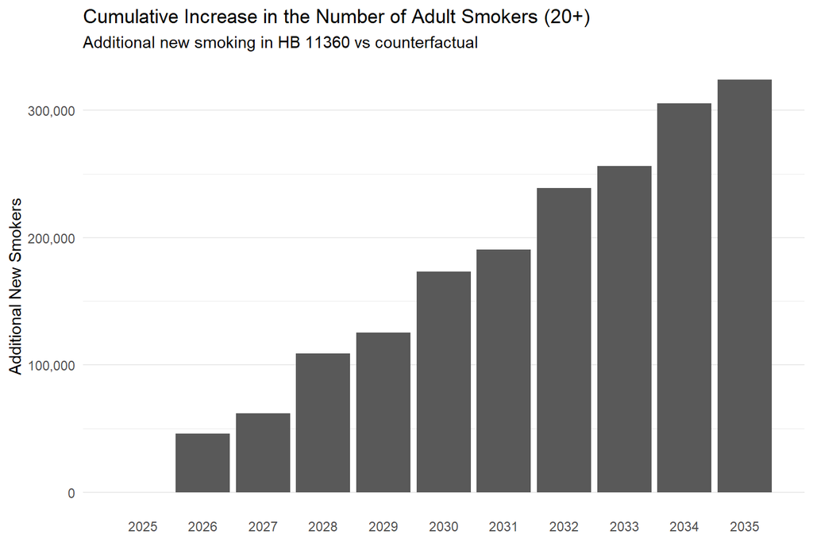

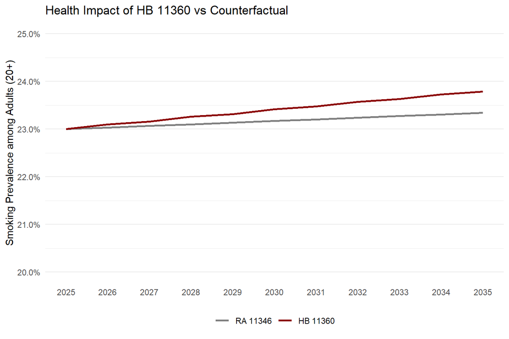